# CAT simulation with customized item selection

Example of how to build a unidimensional CAT simulation using a customized item selection function. This example also showcases some of the more low-level features of this approach by also supplying person information through the `person_properties` input.

This example attempts to select items which are less optimal, in the sense of maximally reducing measurement error, and instead selects items according to an expected probability of response rule. Namely, items are selected whereby their expected probability of answering any given item is some value — hence, the items can be much easier/harder than what is typically desired in CATs (which generally aims for 0.5).

This kind of selection process might be better for younger children, for example, so that they do not get frustrated by seeing items that are too difficult approximately 50% of the time (e.g., by the end of the CAT they might have a 80% chance of answering any given item correctly). The simulation example below sets up different selection rules for 4 different age categories (ages 5:8), where the probability of correct endorsement decreases from .80 to .50 for older participants.

```r
library(mirtCAT)
# custom next item function (start off with browser to interact with internal objects)
customNextItem <- function(design, person, test){
    browser()
    extract.mirtCAT(person, 'items_answered') #vector of answered items and their order
}
```

To safely extract elements from the defined objects see the `?extract.mirtCAT` help file. To further see how to safely extract elements from objects defined by `mirt`, see the `?extract.mirt` help file.

```r
# real definition
customNextItem <- function(design, person, test){
    theta <- extract.mirtCAT(person, 'thetas')
    mo <- extract.mirtCAT(test, 'mo')
    items_in_bank <- extract.mirtCAT(person, 'items_in_bank')
    p <- rep(NA, extract.mirt(mo, 'nitems'))
    for(i in items_in_bank){
        item <- extract.item(mo, i)
        p[i] <- probtrace(item, theta)[2L]
    }
    pp <- extract.mirtCAT(design, "person_properties")
    ID <- extract.mirtCAT(person, "ID") #row associated with person_properties
    e <- switch(as.character(pp[ID, ]), "5" = .80, "6" = .70, "7" = .60, "8" = .50)
    diff <- (p - e)^2
    ret <- which(min(diff, na.rm = TRUE) == diff)[1L] # always return the first element
    ret
}

# simulation
set.seed(1)
nitems <- 300
N <- 200
Theta <- matrix(rnorm(N)) + rep(c(-0.75, -0.25, 0.25, 0.75), each = 50)
a <- matrix(rlnorm(nitems, .2, .3), nitems)
d <- rnorm(nitems)
pars <- data.frame(a1 = a, d = d, g = 0.2)
mirt_object <- generate.mirt_object(pars, '3PL')
responses <- generate_pattern(mirt_object, Theta = Theta)

# different age group information
person_properties <- data.frame(age = rep(5:8, each = 50))

library(parallel)
cl <- makeCluster(detectCores())
design <- list(min_SEM = .3, min_items = 10, max_items = 50,
               customNextItem=customNextItem, person_properties=person_properties)
mirtCAT_results <- mirtCAT(mo = mirt_object, local_pattern = responses,
                           start_item = 1, design = design, cl = cl)
stopCluster(cl)
```

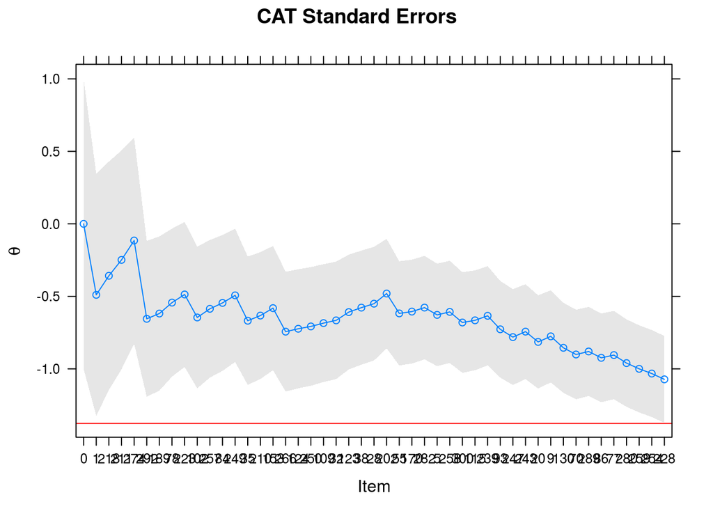

```r
# individual response pattern plot
plot(mirtCAT_results[[1]])
```

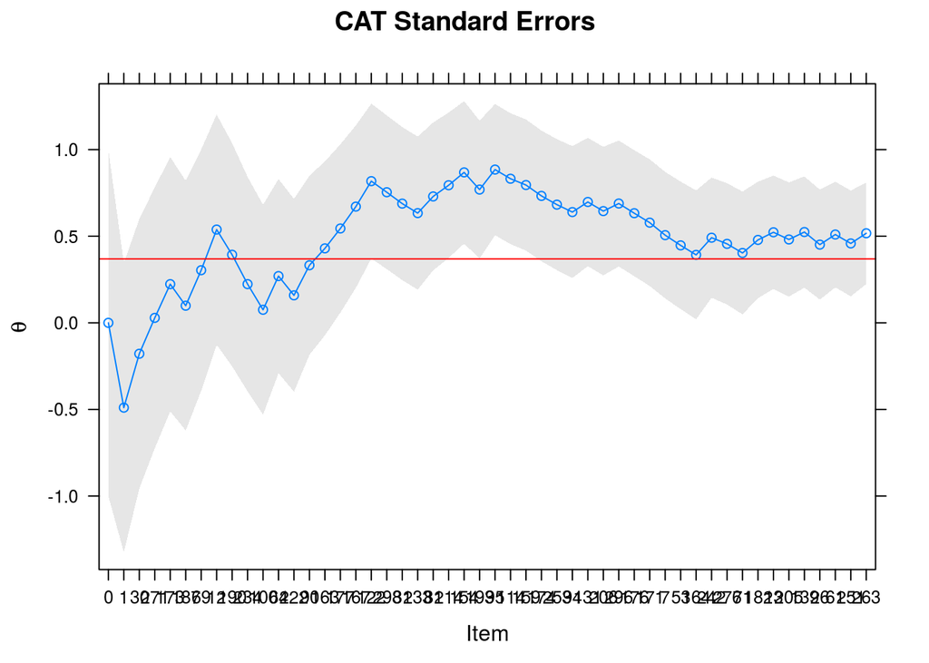

```r
plot(mirtCAT_results[[200]])
```

```r
# average number of items answered correctly for each age group
mean(sapply(1:50, function(x) mean(mirtCAT_results[[x]]$scored_responses, na.rm = TRUE)))
```

```
## [1] 0.6801318
```

```r
mean(sapply(51:100, function(x) mean(mirtCAT_results[[x]]$scored_responses, na.rm = TRUE)))
```

```
## [1] 0.6716018
```

```r
mean(sapply(101:150, function(x) mean(mirtCAT_results[[x]]$scored_responses, na.rm = TRUE)))
```

```
## [1] 0.5971916
```

```r
mean(sapply(151:200, function(x) mean(mirtCAT_results[[x]]$scored_responses, na.rm = TRUE)))
```

```
## [1] 0.5937333
```

```r
# ability estimates by age
thetas <- sapply(mirtCAT_results, function(x) x$thetas)
summary(lm(thetas ~ factor(person_properties$age)))
```

```
##
## Call:
## lm(formula = thetas ~ factor(person_properties$age))
##
## Residuals:
##      Min       1Q   Median       3Q      Max
## -2.12293 -0.55866 -0.06072  0.60799  2.31209
##
## Coefficients:
##                                Estimate Std. Error t value Pr(>|t|)
## (Intercept)                     -0.6306     0.1267  -4.976 1.42e-06 ***
## factor(person_properties$age)6   0.5194     0.1792   2.898  0.00418 **
## factor(person_properties$age)7   0.6996     0.1792   3.903  0.00013 ***
## factor(person_properties$age)8   1.4370     0.1792   8.018 9.56e-14 ***
## ---
## Signif. codes:  0 '***' 0.001 '**' 0.01 '*' 0.05 '.' 0.1 ' ' 1
##
## Residual standard error: 0.8961 on 196 degrees of freedom
## Multiple R-squared:  0.252,  Adjusted R-squared:  0.2405
## F-statistic: 22.01 on 3 and 196 DF,  p-value: 2.508e-12
```

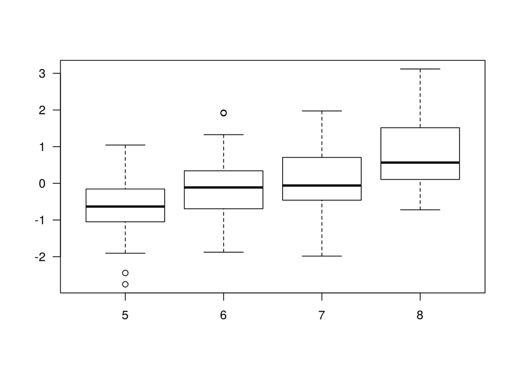

```r
boxplot(thetas ~ factor(person_properties$age), las=1)
```

Notice that although age group 5 had the lowest ability levels overall they answered the highest number of items correctly. This should seem contrary to what would be expected, because this group should have answered the fewest number of items correctly. However, given the customized item selection scheme these individuals were more likely to receive much easier items than they normally would have. The converse is true age group 8.